# R Basics

Jiuru Lyu

2022-10-09

# Data Basics

## Import Data

```r
gss <- read.csv('gss.csv')
```

Using this method to import data, we need to make sure the data set is saved in the same folder with this .rmd file. This “same folder” is called the working directory.

To view the data set, we can use the function `View()`. Remember R is capital-sensitive. and we have to make sure the V is capitalized

## Functions for a Data Frame

Using the `summary()` function, we can get a summary of all variables in the data frame. For numeric values, we will get basic statistical information by using the `summary()` function.

```r
summary(gss)
```

```
##        X            region             income             happy
##  Min.   :    1   Length:53474       Length:53474       Length:53474
##  1st Qu.:13369   Class :character   Class :character   Class :character
##  Median :26738   Mode  :character   Mode  :character   Mode  :character
##  Mean   :26738
##  3rd Qu.:40106
##  Max.   :53474
##
##       age          finrela            marital             degree
##  Min.   :18.00   Length:53474       Length:53474       Length:53474
##  1st Qu.:31.00   Class :character   Class :character   Class :character
##  Median :43.00   Mode  :character   Mode  :character   Mode  :character
##  Mean   :45.63
##  3rd Qu.:59.00
##  Max.   :99.00
##  NA's   :189
##     health            wrkstat            partyid            polviews
##  Length:53474       Length:53474       Length:53474       Length:53474
##  Class :character   Class :character   Class :character   Class :character
##  Mode  :character   Mode  :character   Mode  :character   Mode  :character
##
##
##
##
##      sex                 year
##  Length:53474       Min.   :1973
##  Class :character   1st Qu.:1983
##  Mode  :character   Median :1993
##                     Mean   :1992
##                     3rd Qu.:2002
##                     Max.   :2010
##
```

Using the `head()` function, we will get the first 6 rows of the data frame.

```r
head(gss)
```

```
##   X          region         income         happy age finrela  marital
## 1 1 E. NOR. CENTRAL $10000 - 14999 NOT TOO HAPPY  54 AVERAGE  MARRIED
## 2 2 E. NOR. CENTRAL  $7000 TO 7999    VERY HAPPY  51 AVERAGE  MARRIED
## 3 3 E. NOR. CENTRAL $10000 - 14999  PRETTY HAPPY  36 AVERAGE  MARRIED
## 4 4 E. NOR. CENTRAL $10000 - 14999  PRETTY HAPPY  32 AVERAGE  MARRIED
## 5 5 E. NOR. CENTRAL $10000 - 14999  PRETTY HAPPY  54 AVERAGE  MARRIED
## 6 6 MIDDLE ATLANTIC $10000 - 14999  PRETTY HAPPY  41 AVERAGE DIVORCED
##           degree    health          wrkstat          partyid polviews    sex
## 1 LT HIGH SCHOOL      FAIR WORKING FULLTIME      OTHER PARTY     <NA>   MALE
## 2 LT HIGH SCHOOL      GOOD    KEEPING HOUSE NOT STR DEMOCRAT     <NA> FEMALE
## 3 LT HIGH SCHOOL EXCELLENT WORKING FULLTIME     IND NEAR REP     <NA> FEMALE
## 4    HIGH SCHOOL EXCELLENT WORKING FULLTIME NOT STR DEMOCRAT     <NA>   MALE
## 5 LT HIGH SCHOOL      GOOD    KEEPING HOUSE     IND NEAR REP     <NA> FEMALE
## 6    HIGH SCHOOL      GOOD WORKING FULLTIME NOT STR DEMOCRAT     <NA> FEMALE
##   year
## 1 1973
## 2 1973
## 3 1973
## 4 1973
## 5 1973
## 6 1973
```

Using the `tail()` function, in contrast, we will get the last 6 rows of the data frame.

```r
tail(gss)
```

```
##           X  region         income         happy age           finrela
## 53469 53469 PACIFIC $25000 OR MORE NOT TOO HAPPY  63     BELOW AVERAGE
## 53470 53470 PACIFIC $25000 OR MORE  PRETTY HAPPY  62     ABOVE AVERAGE
## 53471 53471 PACIFIC $10000 - 14999 NOT TOO HAPPY  66 FAR ABOVE AVERAGE
## 53472 53472 PACIFIC $20000 - 24999    VERY HAPPY  54           AVERAGE
## 53473 53473 PACIFIC  $6000 TO 6999  PRETTY HAPPY  57     BELOW AVERAGE
## 53474 53474 PACIFIC $25000 OR MORE  PRETTY HAPPY  30     BELOW AVERAGE
##             marital      degree    health          wrkstat           partyid
## 53469      DIVORCED HIGH SCHOOL      POOR          RETIRED      IND NEAR REP
## 53470       MARRIED    BACHELOR      GOOD          RETIRED STRONG REPUBLICAN
## 53471       WIDOWED HIGH SCHOOL       IAP          RETIRED STRONG REPUBLICAN
## 53472     SEPARATED HIGH SCHOOL       IAP WORKING FULLTIME  NOT STR DEMOCRAT
## 53473      DIVORCED    BACHELOR EXCELLENT WORKING FULLTIME       INDEPENDENT
## 53474 NEVER MARRIED HIGH SCHOOL       IAP WORKING FULLTIME       OTHER PARTY
##                   polviews    sex year
## 53469             MODERATE   MALE 2010
## 53470 SLGHTLY CONSERVATIVE   MALE 2010
## 53471 EXTRMLY CONSERVATIVE FEMALE 2010
## 53472     SLIGHTLY LIBERAL FEMALE 2010
## 53473     SLIGHTLY LIBERAL FEMALE 2010
## 53474             MODERATE   MALE 2010
```

Using `dim()` function, we can check the dimensions of our data set (i.e., how many observations do we have and how many variables do we have.)

```r
dim(gss)
```

```
## [1] 53474    14
```

Using `str()` function, we can get the strcture of our data set.

```r
str(gss)
```

```
## 'data.frame':    53474 obs. of  14 variables:
##  $ X       : int  1 2 3 4 5 6 7 8 9 10 ...
##  $ region  : chr  "E. NOR. CENTRAL" "E. NOR. CENTRAL" "E. NOR. CENTRAL" "E. NOR. CENTRAL" ...
##  $ income  : chr  "$10000 - 14999" "$7000 TO 7999" "$10000 - 14999" "$10000 - 14999" ...
##  $ happy   : chr  "NOT TOO HAPPY" "VERY HAPPY" "PRETTY HAPPY" "PRETTY HAPPY" ...
##  $ age     : int  54 51 36 32 54 41 31 26 78 46 ...
##  $ finrela : chr  "AVERAGE" "AVERAGE" "AVERAGE" "AVERAGE" ...
##  $ marital : chr  "MARRIED" "MARRIED" "MARRIED" "MARRIED" ...
##  $ degree  : chr  "LT HIGH SCHOOL" "LT HIGH SCHOOL" "LT HIGH SCHOOL" "HIGH SCHOOL" ...
##  $ health  : chr  "FAIR" "GOOD" "EXCELLENT" "EXCELLENT" ...
##  $ wrkstat : chr  "WORKING FULLTIME" "KEEPING HOUSE" "WORKING FULLTIME" "WORKING FULLTIME" ...
##  $ partyid : chr  "OTHER PARTY" "NOT STR DEMOCRAT" "IND NEAR REP" "NOT STR DEMOCRAT" ...
##  $ polviews: chr  NA NA NA NA ...
##  $ sex     : chr  "MALE" "FEMALE" "FEMALE" "MALE" ...
##  $ year    : int  1973 1973 1973 1973 1973 1973 1973 1973 1973 1973 ...
```

Using `names()` we can get the names of all variables of the data set.

```r
names(gss)
```

```
##  [1] "X"        "region"   "income"   "happy"    "age"      "finrela"
##  [7] "marital"  "degree"   "health"   "wrkstat"  "partyid"  "polviews"
## [13] "sex"      "year"
```

## Extract Elements form a Data Frame

A data frame is a matrix, which is two dimensional, including rows and columns.

- If we want to extract elements from a data frame (which is 2 dimensional), we use `df_name[row_num, col_num]`.

```r
gss[1,2]
```

```
## [1] "E. NOR. CENTRAL"
```

- If we want to extract all rows or all columns, we just omit the argument. For example, `gss[,2]` extracts all rows in the second columns of the data frame gss.

```r
gss[2,]
```

```
##   X          region        income      happy age finrela marital         degree
## 2 2 E. NOR. CENTRAL $7000 TO 7999 VERY HAPPY  51 AVERAGE MARRIED LT HIGH SCHOOL
##   health       wrkstat          partyid polviews    sex year
## 2   GOOD KEEPING HOUSE NOT STR DEMOCRAT     <NA> FEMALE 1973
```

- If we want to extract a continuous range of rows or columns from the data frame, we use `:` sign. For example, `gss[1:100, 1:3]` extracts the first 100 rows and the first 3 columns of the data frame

```
## 'data.frame':    100 obs. of  3 variables:
##  $ X     : int  1 2 3 4 5 6 7 8 9 10 ...
##  $ region: chr  "E. NOR. CENTRAL" "E. NOR. CENTRAL" "E. NOR. CENTRAL" "E. NOR. CENTRAL" ...
##  $ income: chr  "$10000 - 14999" "$7000 TO 7999" "$10000 - 14999" "$10000 - 14999" ...
```

- If we want to extract a range of rows or columns that are not continuous, we can use the `c()` function. For example, `gss[c(2, 4, 6), c(2, 4, 5)]` extracts the second, forth, and sixth rows of the data set, as well as the second, forth, and fifth columns of the data set.

```r
gss[c(2, 4, 6), c(2, 4, 5)]
```

```
##            region        happy age
## 2 E. NOR. CENTRAL   VERY HAPPY  51
## 4 E. NOR. CENTRAL PRETTY HAPPY  32
## 6 MIDDLE ATLANTIC PRETTY HAPPY  41
```

- If we want the majority of the rows or columns, except for some columns, we can use the `-` sign. For example, `gss[-c(1, 3), -c(1, 5)]` extracts all the rows except the first and third ones and all the columns except the first and the fifth ones.

```
## 'data.frame':    53472 obs. of  12 variables:
##  $ region  : chr  "E. NOR. CENTRAL" "E. NOR. CENTRAL" "E. NOR. CENTRAL" "MIDDLE ATLANTIC" ...
##  $ income  : chr  "$7000 TO 7999" "$10000 - 14999" "$10000 - 14999" "$10000 - 14999" ...
##  $ happy   : chr  "VERY HAPPY" "PRETTY HAPPY" "PRETTY HAPPY" "PRETTY HAPPY" ...
##  $ finrela : chr  "AVERAGE" "AVERAGE" "AVERAGE" "AVERAGE" ...
##  $ marital : chr  "MARRIED" "MARRIED" "MARRIED" "DIVORCED" ...
##  $ degree  : chr  "LT HIGH SCHOOL" "HIGH SCHOOL" "LT HIGH SCHOOL" "HIGH SCHOOL" ...
##  $ health  : chr  "GOOD" "EXCELLENT" "GOOD" "GOOD" ...
##  $ wrkstat : chr  "KEEPING HOUSE" "WORKING FULLTIME" "KEEPING HOUSE" "WORKING FULLTIME" ...
##  $ partyid : chr  "NOT STR DEMOCRAT" "NOT STR DEMOCRAT" "IND NEAR REP" "NOT STR DEMOCRAT" ...
##  $ polviews: chr  NA NA NA NA ...
##  $ sex     : chr  "FEMALE" "MALE" "FEMALE" "FEMALE" ...
##  $ year    : int  1973 1973 1973 1973 1973 1973 1973 1973 1973 1973 ...
```

## Save Data

```r
getwd()
```

```
## [1] "/Users/richardlyu/Library/CloudStorage/OneDrive-EmoryUniversity/2 Freshman/1 Fall 2022/QTM 150/Lecture/Personal Notes"
```

## Create a Random Sample

```r
sample(1:20, 5)
```

```
## [1] 12 20  9  5 10
```

There is an argument called `replace`, and the default value of it is `FALSE`, meaning we are creating a random sample without replacement (each element from the random sample is unique). If you want to create a random sample WITH replacement (after selecting an element, put it back and then select another - you might get repetitive elements in the random sample), specify the value to `TRUE` by including `replace = TRUE`.

```r
sample(1:20, 5, replace = TRUE)
```

```
## [1]  8  3 15 10  2
```

# Vector

In R, almost everything is a vector. All elements (values) of a vector must be in the same type.

Vector, including list, factor, matrix, data frame, are called objects in R.

## Numeric Vectors

A numeric vector is a list of numbers. Integer and double vectors are known collectively as numeric vectors. (Doubles represent floating point numbers that can not always be precisely represented with a fixed amount of memory.)

The `c()` function is used to create a vector.

```r
a <- c(1, 2, 3)
a
```

```
## [1] 1 2 3
```

The sign `:` creates a continuous list from the starting number ot the ending number with a step of 1.

```r
x <- c(1:10)
x
```

```
##  [1]  1  2  3  4  5  6  7  8  9 10
```

You can also create a numeric vector in descending order:

```r
y <- c(30:1)
y
```

```
##  [1] 30 29 28 27 26 25 24 23 22 21 20 19 18 17 16 15 14 13 12 11 10  9  8  7  6
## [26]  5  4  3  2  1
```

We can use the square bracket (`[]`) to extract elements from the vector.

```r
x[5]
```

```
## [1] 5
```

```r
x[c(3:7)]
```

```
## [1] 3 4 5 6 7
```

```r
x[3:7]
```

```
## [1] 3 4 5 6 7
```

The minus sign (`-`) tells R the index numbers of the elements that we do not want to extract.

```r
x[-c(1, 3, 5, 7, 9)]
```

```
## [1]  2  4  6  8 10
```

### Common Functions for Numeric Vectors: `seq()`, `rep()`, and `sample()`

Using the `seq()` function, we can create a sequence from a starting number to an ending number with a specified step. If the step is not specified, the step is set to `1` by default. The syntax of `seq()` is:

```
seq(starting, ending, by = step)
```

```r
# Create a sequence from 0 to 100 by a step of 5.
seq(0, 100, by = 5)
```

```
##  [1]   0   5  10  15  20  25  30  35  40  45  50  55  60  65  70  75  80  85  90
## [20]  95 100
```

```r
# Get all odd numbers ranged from 1 to 20.
seq(1, 20, by = 2)
```

```
##  [1]  1  3  5  7  9 11 13 15 17 19
```

```r
# If we omit the `by` argument, we will create a sequence with a step of 1
seq(1, 20)
```

```
##  [1]  1  2  3  4  5  6  7  8  9 10 11 12 13 14 15 16 17 18 19 20
```

Using the `rep()` function (the repeat function), you can specify the object you want to repeat and the number of times you want to repeat. The syntax goes by:

```
rep(x, times of repetition)
```

```r
# Repeat 2 fir 5 times:
rep(2, 5)
```

```
## [1] 2 2 2 2 2
```

```r
# Even more complicated objects can be repeated:
x <- (1:5)
y <- (10:15)
  # Repeat the vector `c(x,y)` twice
rep(c(x,y), 2)
```

```
##  [1]  1  2  3  4  5 10 11 12 13 14 15  1  2  3  4  5 10 11 12 13 14 15
```

Using the `sample()` function, we can get a random sample for the specified vector. THe syntax goes by:

```
sample(vector, sample size, replace = TRUE/FALSE)
```

`TRUE` and `FALSE` can be simplified into `T` and `F`.

```r
sample(1:10, 3, replace = F)
```

```
## [1] 10  2  3
```

If we use `set.seed()` with a number, we are fixing the starting point to get a random sample. In other words, it allows us the get the same sample when the code is executed each time. We can put any numbers in the `set.seed()`.

Different numbers in the `set.seed()` will leads to different random samples chosen; however, once the number in the `set.seed()` is fixed, we will only get one unique random sample each time we run the code.

```r
set.seed(344)

sample(1:10, 3, replace = F)
```

```
## [1] 3 1 6
```

```r
# Before we start collecting a random sample, we want to now how many rows do we have in this data set.
dim(gss)
```

```
## [1] 53474    14
```

```r
# We can also use nrow() to only get the row number.
nrow(gss)
```

```
## [1] 53474
```

```r
set.seed(1)
random_sample <- gss[sample(1:53474, 100, replace = FALSE), ]

head(random_sample)
```

```
##           X          region         income        happy age       finrela
## 24388 24388 E. NOR. CENTRAL $25000 OR MORE   VERY HAPPY  51       AVERAGE
## 43307 43307 E. NOR. CENTRAL  $4000 TO 4999         <NA>  29          <NA>
## 4050   4050  SOUTH ATLANTIC $10000 - 14999 PRETTY HAPPY  37 BELOW AVERAGE
## 11571 11571  SOUTH ATLANTIC  $4000 TO 4999 PRETTY HAPPY  30 BELOW AVERAGE
## 25173 25173 E. NOR. CENTRAL $25000 OR MORE PRETTY HAPPY  37 ABOVE AVERAGE
## 32618 32618 W. SOU. CENTRAL $25000 OR MORE PRETTY HAPPY  52 ABOVE AVERAGE
##             marital         degree    health          wrkstat         partyid
## 24388       MARRIED    HIGH SCHOOL      <NA> WORKING FULLTIME STRONG DEMOCRAT
## 43307 NEVER MARRIED    HIGH SCHOOL      <NA>    KEEPING HOUSE    IND NEAR DEM
## 4050        MARRIED    HIGH SCHOOL EXCELLENT WORKING FULLTIME STRONG DEMOCRAT
## 11571     SEPARATED LT HIGH SCHOOL      FAIR WORKING PARTTIME STRONG DEMOCRAT
## 25173       MARRIED    HIGH SCHOOL      <NA> WORKING FULLTIME     OTHER PARTY
## 32618       MARRIED JUNIOR COLLEGE      GOOD WORKING FULLTIME STRONG DEMOCRAT
##                   polviews    sex year
## 24388             MODERATE   MALE 1990
## 43307                 <NA> FEMALE 2004
## 4050  SLGHTLY CONSERVATIVE   MALE 1975
## 11571             MODERATE FEMALE 1982
## 25173                 <NA>   MALE 1991
## 32618 SLGHTLY CONSERVATIVE   MALE 1996
```

The average age in the random sample: 44.53.

### Arithmetic Operators for Numeric Vectors

```r
x <- c(1:5)
x
```

```
## [1] 1 2 3 4 5
```

For example, if we write `x*2`, each element in `x` will be multiplied by 2.

```r
x*2
```

```
## [1]  2  4  6  8 10
```

```r
# Find the sqaure of x
x^2
```

```
## [1]  1  4  9 16 25
```

*Example* We want to find how many years have passed since people in the `gss` data set have taken the survey.

```r
year_passed <- 2022 - gss$year

head(year_passed)
```

```
## [1] 49 49 49 49 49 49
```

```r
x %% 7
```

```
## [1] 1 2 3 4 5
```

If two vectors have the same size, we can plus or minus them.

```r
y <- c(6:10)

x + y
```

```
## [1]  7  9 11 13 15
```

We can also apply simple statistical functions to the vector.

```r
sum(random_sample$age)
```

```
## [1] 4453
```

```r
mean(random_sample$age)
```

```
## [1] 44.53
```

```r
length(random_sample$age)
```

```
## [1] 100
```

### Plots of Numeric Vectors

If we only have one variable, we can create box plot or histograms using `boxplot()` and `hist()`, respectively.

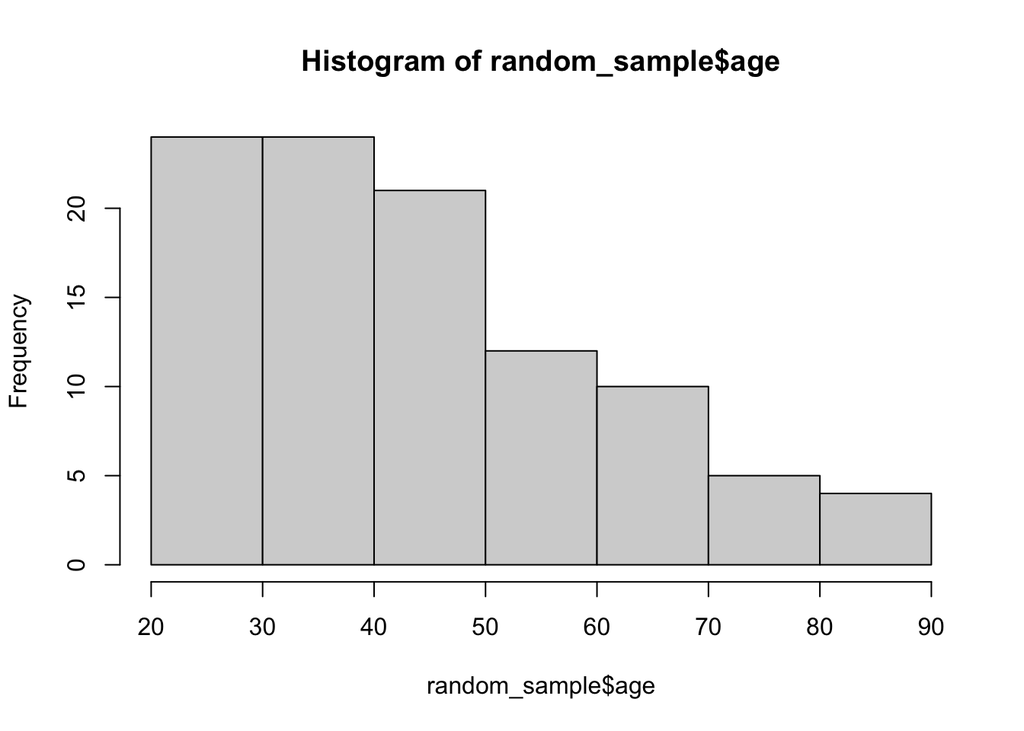

```r
hist(random_sample$age)
```

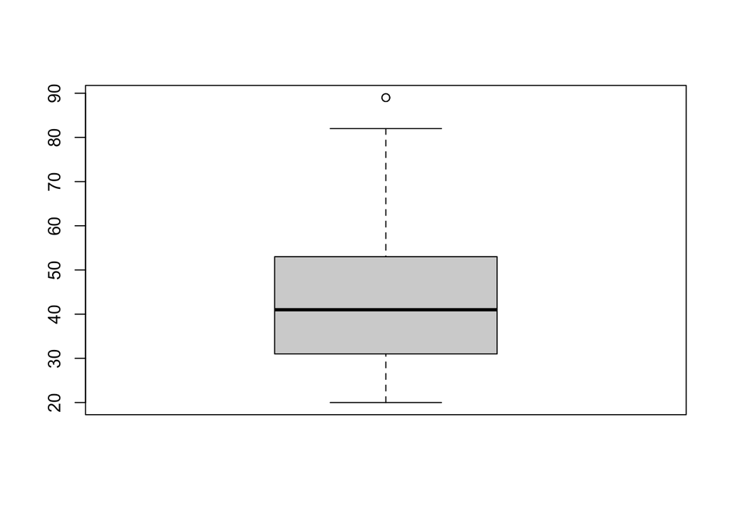

```r
boxplot(random_sample$age)
```

If we have two quantitative variables, we will use scatter plot to present them. The syntax goes by:

```
plot(x, y)
```

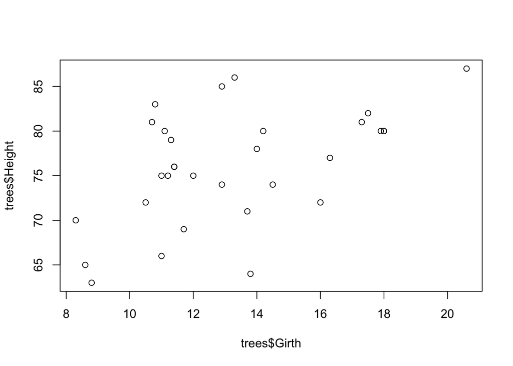

```r
plot(trees$Girth, trees$Height)
```

```r
# The data set trees is pre-set into R.
```

## Character Vector

Vectors can be made up of strings of characters instead of numbers.

```r
schoolyear <- c('Freshman', 'Sophomore', 'Junior', 'Senior')

schoolyear
```

```
## [1] "Freshman"  "Sophomore" "Junior"    "Senior"
```

We can give the names to the numeric vector with the character vector by using the `name()` function. The syntax goes by:

```
names(numeric_vector) <- character_vector
```

```r
year <- c(1, 2, 3, 4)

names(year) <- schoolyear

year
```

```
##  Freshman Sophomore    Junior    Senior
##         1         2         3         4
```

### Common Functions for Character Vectors

There are two basic operations you might want to perform on character vectors: `substr()` and `paste()`.

The syntax of `substr()` goes by:

```
substr(vector, start, end)
```

where `vector` is the vector of characters(strings), and `start` and`*stop` say which characters to keep.

```r
substr(schoolyear, 1, 2)
```

```
## [1] "Fr" "So" "Ju" "Se"
```

The other function `paste()` is used to build up strings by concatenation.

```r
schoolyear1 <- paste(schoolyear, 'Year')

schoolyear1
```

```
## [1] "Freshman Year"  "Sophomore Year" "Junior Year"    "Senior Year"
```

If you want to separate the text string, you can specify the `sep` argument. Some common choices for the `sep` argument are `" "` and `"/"`.

```r
paste('The', schoolyear, 'Year', sep = '/')
```

```
## [1] "The/Freshman/Year"  "The/Sophomore/Year" "The/Junior/Year"
## [4] "The/Senior/Year"
```

Another common function is `tolower()` and `toupper()`. Those are functions to convert the text strings into upper case and lower case.

```r
tolower(schoolyear)
```

```
## [1] "freshman"  "sophomore" "junior"    "senior"
```

*Example* There is a pre-set data set in R called `state.name`.

```r
state.name
```

```
##  [1] "Alabama"        "Alaska"         "Arizona"        "Arkansas"
##  [5] "California"     "Colorado"       "Connecticut"    "Delaware"
##  [9] "Florida"        "Georgia"        "Hawaii"         "Idaho"
## [13] "Illinois"       "Indiana"        "Iowa"           "Kansas"
## [17] "Kentucky"       "Louisiana"      "Maine"          "Maryland"
## [21] "Massachusetts"  "Michigan"       "Minnesota"      "Mississippi"
## [25] "Missouri"       "Montana"        "Nebraska"       "Nevada"
## [29] "New Hampshire"  "New Jersey"     "New Mexico"     "New York"
## [33] "North Carolina" "North Dakota"   "Ohio"           "Oklahoma"
## [37] "Oregon"         "Pennsylvania"   "Rhode Island"   "South Carolina"
## [41] "South Dakota"   "Tennessee"      "Texas"          "Utah"
## [45] "Vermont"        "Virginia"       "Washington"     "West Virginia"
## [49] "Wisconsin"      "Wyoming"
```

1. Use `tolower` or `toupper` to convert the state names into lower cases.

```r
tolower(state.name)
```

```
##  [1] "alabama"        "alaska"         "arizona"        "arkansas"
##  [5] "california"     "colorado"       "connecticut"    "delaware"
##  [9] "florida"        "georgia"        "hawaii"         "idaho"
## [13] "illinois"       "indiana"        "iowa"           "kansas"
## [17] "kentucky"       "louisiana"      "maine"          "maryland"
## [21] "massachusetts"  "michigan"       "minnesota"      "mississippi"
## [25] "missouri"       "montana"        "nebraska"       "nevada"
## [29] "new hampshire"  "new jersey"     "new mexico"     "new york"
## [33] "north carolina" "north dakota"   "ohio"           "oklahoma"
## [37] "oregon"         "pennsylvania"   "rhode island"   "south carolina"
## [41] "south dakota"   "tennessee"      "texas"          "utah"
## [45] "vermont"        "virginia"       "washington"     "west virginia"
## [49] "wisconsin"      "wyoming"
```

2. Extract the first letter of the state names.

```r
substr(state.name, 1, 1)
```

```
##  [1] "A" "A" "A" "A" "C" "C" "C" "D" "F" "G" "H" "I" "I" "I" "I" "K" "K" "L" "M"
## [20] "M" "M" "M" "M" "M" "M" "M" "N" "N" "N" "N" "N" "N" "N" "N" "O" "O" "O" "P"
## [39] "R" "S" "S" "T" "T" "U" "V" "V" "W" "W" "W" "W"
```

### Plots of Character Vector / Categorical Variable

We can use the `table()` function to create a frequency table. The frequency table is the approach to summarize character vectors.

```r
table(random_sample$region)
```

```
##
## E. NOR. CENTRAL E. SOU. CENTRAL MIDDLE ATLANTIC        MOUNTAIN     NEW ENGLAND
##              18              10              16               2               2
##         PACIFIC  SOUTH ATLANTIC W. NOR. CENTRAL W. SOU. CENTRAL
##              18              19               1              14
```

```r
table(random_sample$sex)
```

```
##
## FEMALE   MALE
##     51     49
```

We can use `prop.table()` to calculate the percentage of each category in the categorical variable. The syntax goes by:

```
prop.table(frequency_table))
```

If we did not have a frequency table, we need to put the `table()` function inside the the `prop.table()` function. For example:

```r
prop.table(table(random_sample$sex))
```

```
##
## FEMALE   MALE
##   0.51   0.49
```

The suitable plot to present categorical variables, we should use a bar plot. The syntax goes by:

```
barplot(frequency_table)
```

In a bar plot, the $x$-axis will be the category, and the $y$-axis will be the frequency.

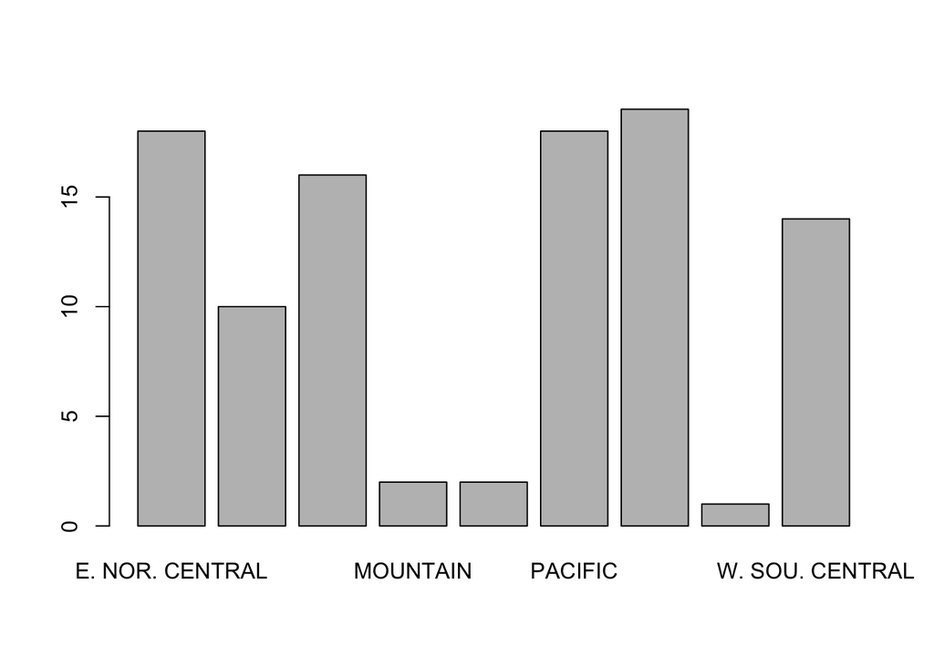

```r
barplot(table(random_sample$region))
```

We can also create the plot using the proportion frequency table:

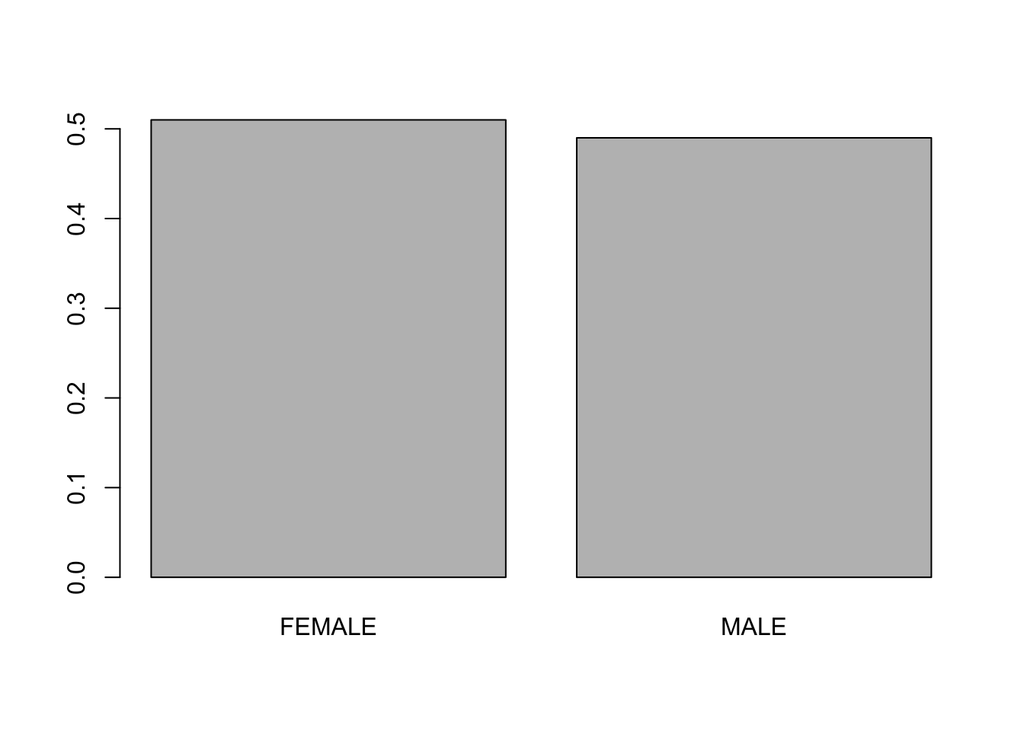

```r
barplot(prop.table(table(random_sample$sex)))
```

If we have two categorical variables, we will create the **contingency table**. To create a contingency table, we will also use the `table()` function, but with different syntax:

```
table(x, y)
```

where `x` and `y` are two different categorical variables.

```r
table(random_sample$sex, random_sample$marital)
```

```
##
##          DIVORCED MARRIED NEVER MARRIED SEPARATED WIDOWED
##   FEMALE        6      28             7         4       6
##   MALE          6      35             7         1       0
```

Usually, the first categorical variable will be presented vertically on the left, and the second categorical variable will be presented horizontally on the top.

Again, we can also use `prop.table()` to create a proportion contingency table.

```r
prop.table(table(random_sample$sex, random_sample$marital))
```

```
##
##          DIVORCED MARRIED NEVER MARRIED SEPARATED WIDOWED
##   FEMALE     0.06    0.28          0.07      0.04    0.06
##   MALE       0.06    0.35          0.07      0.01    0.00
```

However, `prop.table()` will only give as the overall proportion (or total proportion). Sometimes, we want the margin proportion, so we need to specify the value of argument `margin` in the `prop.table()`.

If `margin = 1`, we are creating a row marginal proportion table. In a row marginal proportion table, the sum of the row is calculated first, and the proportion of each character variable is calculated in relating to the row sum.

```r
prop.table(table(random_sample$sex, random_sample$marital), margin = 1)
```

```
##
##            DIVORCED    MARRIED NEVER MARRIED  SEPARATED    WIDOWED
##   FEMALE 0.11764706 0.54901961    0.13725490 0.07843137 0.11764706
##   MALE   0.12244898 0.71428571    0.14285714 0.02040816 0.00000000
```

If we set `margin = 2`, a column marginal proportion table is created. In a column marginal proportion table, the sum of the column is first calculated, and then the proportion of each character variable is calculated with respect the the column sum.

```r
prop.table(table(random_sample$sex, random_sample$marital), margin = 2)
```

```
##
##           DIVORCED   MARRIED NEVER MARRIED SEPARATED   WIDOWED
##   FEMALE 0.5000000 0.4444444     0.5000000 0.8000000 1.0000000
##   MALE   0.5000000 0.5555556     0.5000000 0.2000000 0.0000000
```

If you want to calculate the row total and the column total, we should use the `marginSum()` function.

```
marginSum(frequency_table, margin = 1)
```

If the `margin` is set to `1`, we are calculating the row total. If the `margin` is set to `2`, we are calculating the column total.

```r
marginSums(table(random_sample$sex, random_sample$marital), margin = 1)
```

```
##
## FEMALE   MALE
##     51     49
```

```r
marginSums(table(random_sample$sex, random_sample$marital), margin = 2)
```

```
##
##      DIVORCED       MARRIED NEVER MARRIED     SEPARATED       WIDOWED
##            12            63            14             5             6
```

To visualization, we will also use the `barplot()` function.

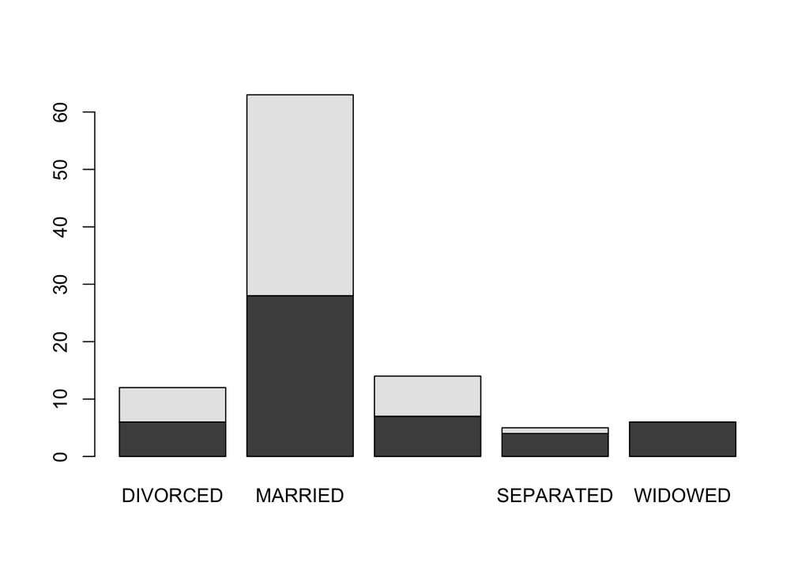

```r
barplot(table(random_sample$sex, random_sample$marital))
```

The argument `col` is used to set the color of the plot.

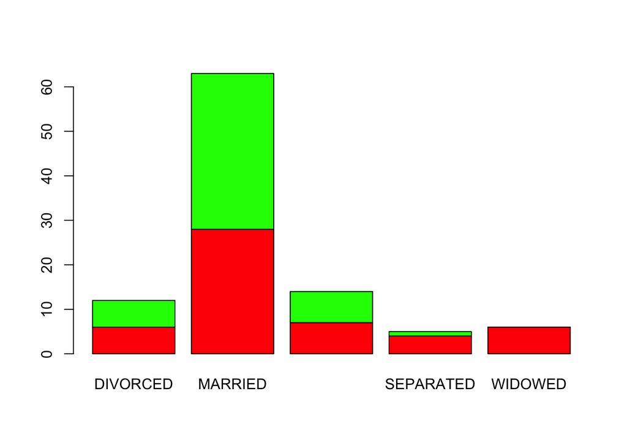

```r
barplot(table(random_sample$sex, random_sample$marital), col=c('red', 'green'))
```

## Logical Vector

There are only two values for a logical vector - `TRUE` or `FALSE`. It is often necessary to test relations when programming. R allows testing of equality and inequality relations using the relational operators:

1. greater than: `>`,
2. less than: `<`,
3. equality: `==`,
4. inequality: `!=`, `>=`, `<=`,
5. matching: `%in%`.

For example,

```r
x <- c(1:5)

x > 3
```

```
## [1] FALSE FALSE FALSE  TRUE  TRUE
```

```r
3 == 4
```

```
## [1] FALSE
```

```r
schoolyear %in% "Senior"
```

```
## [1] FALSE FALSE FALSE  TRUE
```

As long as the vector matches one value after the `%in%` sign, R will return TRUE:

```r
schoolyear %in% c("Freshman", "Junior")
```

```
## [1]  TRUE FALSE  TRUE FALSE
```

In R, `TRUE` has an internal value of `1`, and `FALSE` has an internal value of `0`. For example, we can sum up a logical vector.

```r
sum(x > 3)
```

```
## [1] 2
```

The logical vectors can also be used to extract subsets by *logical expression*. R will only extract the data with the `TRUE` logical value.

```r
gss_subset <- gss[gss$year == 2010,]

head(gss_subset)
```

```
##           X          region         income         happy age       finrela
## 51431 51431    NOT ASSIGNED $25000 OR MORE  PRETTY HAPPY  31       AVERAGE
## 51432 51432    NOT ASSIGNED $15000 - 19999 NOT TOO HAPPY  23 ABOVE AVERAGE
## 51433 51433 MIDDLE ATLANTIC $20000 - 24999 NOT TOO HAPPY  71 BELOW AVERAGE
## 51434 51434 MIDDLE ATLANTIC  $8000 TO 9999 NOT TOO HAPPY  82       AVERAGE
## 51435 51435 MIDDLE ATLANTIC             DK    VERY HAPPY  78       AVERAGE
## 51436 51436 MIDDLE ATLANTIC $10000 - 14999  PRETTY HAPPY  40       AVERAGE
##             marital         degree health          wrkstat           partyid
## 51431 NEVER MARRIED       BACHELOR    IAP WORKING FULLTIME  NOT STR DEMOCRAT
## 51432 NEVER MARRIED       BACHELOR    IAP WORKING FULLTIME  NOT STR DEMOCRAT
## 51433      DIVORCED LT HIGH SCHOOL   FAIR          RETIRED   STRONG DEMOCRAT
## 51434       WIDOWED LT HIGH SCHOOL    IAP          RETIRED STRONG REPUBLICAN
## 51435       MARRIED LT HIGH SCHOOL   POOR          RETIRED       INDEPENDENT
## 51436 NEVER MARRIED LT HIGH SCHOOL    IAP  UNEMPL LAID OFF   STRONG DEMOCRAT
##               polviews    sex year
## 51431 SLIGHTLY LIBERAL   MALE 2010
## 51432          LIBERAL FEMALE 2010
## 51433               DK FEMALE 2010
## 51434          LIBERAL FEMALE 2010
## 51435 SLIGHTLY LIBERAL FEMALE 2010
## 51436 SLIGHTLY LIBERAL   MALE 2010
```

```r
schoolyear[substr(schoolyear, 1, 1) == "S"]
```

```
## [1] "Sophomore" "Senior"
```

```r
substr(state.name, 1, 1) == "M"
```

```
##  [1] FALSE FALSE FALSE FALSE FALSE FALSE FALSE FALSE FALSE FALSE FALSE FALSE
## [13] FALSE FALSE FALSE FALSE FALSE FALSE  TRUE  TRUE  TRUE  TRUE  TRUE  TRUE
## [25]  TRUE  TRUE FALSE FALSE FALSE FALSE FALSE FALSE FALSE FALSE FALSE FALSE
## [37] FALSE FALSE FALSE FALSE FALSE FALSE FALSE FALSE FALSE FALSE FALSE FALSE
## [49] FALSE FALSE
```

```r
state.name[substr(state.name, 1, 1) == "M"]
```

```
## [1] "Maine"         "Maryland"      "Massachusetts" "Michigan"
## [5] "Minnesota"     "Mississippi"   "Missouri"      "Montana"
```

The logical operators are very useful to get a subset by *subset()*. This function will create the same subsets that we created in the previous section.

```r
subset(schoolyear, substr(schoolyear, 1, 1) == "S")
```

```
## [1] "Sophomore" "Senior"
```

```r
head(subset(gss, year == 2010))
```

```
##           X          region         income         happy age       finrela
## 51431 51431    NOT ASSIGNED $25000 OR MORE  PRETTY HAPPY  31       AVERAGE
## 51432 51432    NOT ASSIGNED $15000 - 19999 NOT TOO HAPPY  23 ABOVE AVERAGE
## 51433 51433 MIDDLE ATLANTIC $20000 - 24999 NOT TOO HAPPY  71 BELOW AVERAGE
## 51434 51434 MIDDLE ATLANTIC  $8000 TO 9999 NOT TOO HAPPY  82       AVERAGE
## 51435 51435 MIDDLE ATLANTIC             DK    VERY HAPPY  78       AVERAGE
## 51436 51436 MIDDLE ATLANTIC $10000 - 14999  PRETTY HAPPY  40       AVERAGE
##             marital         degree health          wrkstat           partyid
## 51431 NEVER MARRIED       BACHELOR    IAP WORKING FULLTIME  NOT STR DEMOCRAT
## 51432 NEVER MARRIED       BACHELOR    IAP WORKING FULLTIME  NOT STR DEMOCRAT
## 51433      DIVORCED LT HIGH SCHOOL   FAIR          RETIRED   STRONG DEMOCRAT
## 51434       WIDOWED LT HIGH SCHOOL    IAP          RETIRED STRONG REPUBLICAN
## 51435       MARRIED LT HIGH SCHOOL   POOR          RETIRED       INDEPENDENT
## 51436 NEVER MARRIED LT HIGH SCHOOL    IAP  UNEMPL LAID OFF   STRONG DEMOCRAT
##               polviews    sex year
## 51431 SLIGHTLY LIBERAL   MALE 2010
## 51432          LIBERAL FEMALE 2010
## 51433               DK FEMALE 2010
## 51434          LIBERAL FEMALE 2010
## 51435 SLIGHTLY LIBERAL FEMALE 2010
## 51436 SLIGHTLY LIBERAL   MALE 2010
```

```r
head(subset(gss, gss$year %in% c(1978, 1984, 2000, 2002, 2004)))
```

```
##         X      region         income        happy age           finrela
## 7508 7508 NEW ENGLAND $10000 - 14999 PRETTY HAPPY  52           AVERAGE
## 7509 7509 NEW ENGLAND  $3000 TO 3999 PRETTY HAPPY  74 FAR BELOW AVERAGE
## 7510 7510 NEW ENGLAND $15000 - 19999   VERY HAPPY  35           AVERAGE
## 7511 7511 NEW ENGLAND $20000 - 24999   VERY HAPPY  50           AVERAGE
## 7512 7512 NEW ENGLAND $20000 - 24999 PRETTY HAPPY  41           AVERAGE
## 7513 7513 NEW ENGLAND $25000 OR MORE   VERY HAPPY  19           AVERAGE
##            marital         degree health          wrkstat          partyid
## 7508       MARRIED    HIGH SCHOOL   <NA>    KEEPING HOUSE  STRONG DEMOCRAT
## 7509       WIDOWED LT HIGH SCHOOL   <NA>    KEEPING HOUSE     IND NEAR REP
## 7510       MARRIED LT HIGH SCHOOL   <NA> WORKING FULLTIME NOT STR DEMOCRAT
## 7511       MARRIED    HIGH SCHOOL   <NA> WORKING FULLTIME  STRONG DEMOCRAT
## 7512       MARRIED    HIGH SCHOOL   <NA> WORKING FULLTIME  STRONG DEMOCRAT
## 7513 NEVER MARRIED    HIGH SCHOOL   <NA> WORKING PARTTIME     IND NEAR DEM
##                  polviews    sex year
## 7508 SLGHTLY CONSERVATIVE FEMALE 1978
## 7509         CONSERVATIVE FEMALE 1978
## 7510     SLIGHTLY LIBERAL   MALE 1978
## 7511     SLIGHTLY LIBERAL FEMALE 1978
## 7512             MODERATE FEMALE 1978
## 7513     SLIGHTLY LIBERAL   MALE 1978
```

### Boolean Operations

The Boolean operations can be encoded in R.

1. *and*: `&`
2. *or*: `|`
3. *not*: `!`

```r
x <- c(1:20)

x
```

```
##  [1]  1  2  3  4  5  6  7  8  9 10 11 12 13 14 15 16 17 18 19 20
```

```r
x1 <- subset(x, x > 10 & x == 12)

x1
```

```
## [1] 12
```

```r
x2 <- x[x <= 5 | x > 14]
x2
```

```
##  [1]  1  2  3  4  5 15 16 17 18 19 20
```

```r
head(gss[gss$year == 2010 | gss$year == 1986, ])
```

```
##           X          region         income         happy age           finrela
## 16974 16974 MIDDLE ATLANTIC $20000 - 24999  PRETTY HAPPY  28 FAR ABOVE AVERAGE
## 16975 16975 MIDDLE ATLANTIC $25000 OR MORE    VERY HAPPY  54 FAR ABOVE AVERAGE
## 16976 16976 MIDDLE ATLANTIC $25000 OR MORE    VERY HAPPY  44     ABOVE AVERAGE
## 16977 16977 MIDDLE ATLANTIC        REFUSED  PRETTY HAPPY  77           AVERAGE
## 16978 16978 MIDDLE ATLANTIC           <NA>  PRETTY HAPPY  44 FAR BELOW AVERAGE
## 16979 16979 MIDDLE ATLANTIC  $5000 TO 5999 NOT TOO HAPPY  47 FAR BELOW AVERAGE
##             marital         degree health          wrkstat           partyid
## 16974 NEVER MARRIED    HIGH SCHOOL   <NA> WORKING FULLTIME       INDEPENDENT
## 16975       WIDOWED       BACHELOR   <NA>    KEEPING HOUSE STRONG REPUBLICAN
## 16976 NEVER MARRIED       BACHELOR   <NA> WORKING FULLTIME   STRONG DEMOCRAT
## 16977     SEPARATED    HIGH SCHOOL   <NA>          RETIRED   STRONG DEMOCRAT
## 16978     SEPARATED JUNIOR COLLEGE   <NA> WORKING PARTTIME   STRONG DEMOCRAT
## 16979     SEPARATED LT HIGH SCHOOL   <NA>    KEEPING HOUSE  NOT STR DEMOCRAT
##                polviews    sex year
## 16974          MODERATE   MALE 1986
## 16975      CONSERVATIVE FEMALE 1986
## 16976           LIBERAL FEMALE 1986
## 16977          MODERATE FEMALE 1986
## 16978          MODERATE FEMALE 1986
## 16979 EXTREMELY LIBERAL   MALE 1986
```

### The `is.XXX()` Functions

`is.na()` and `!is.na()` is used to detect the missing values in the data set.

```r
x <- c(1, 3, 4, NA, 5)

is.na(x)
```

```
## [1] FALSE FALSE FALSE  TRUE FALSE
```

```r
sum(!is.na(x))
```

```
## [1] 4
```

```r
sum(is.na(gss$marital))
```

```
## [1] 20
```

```r
sum(is.na(gss$region))
```

```
## [1] 0
```

```r
sum(is.na(gss$age))
```

```
## [1] 189
```

To calculate mean values of a data set with NAs, we can use the following code:

```r
mean(gss$age, na.rm = TRUE)
```

```
## [1] 45.63128
```

The argument `na.rm=TRUE` tells R to omit NAs when calculating the mean.

We can use other `is.vectortype()` vector to check the type of the vector.

1. Check if the vector is a character vector: `is.character()`
2. Check if the vector is a numeric vector: `is nemeric()`

```r
is.character(gss$region)
```

```
## [1] TRUE
```

```r
is.numeric(gss$income)
```

```
## [1] FALSE
```

# Factors

The data frames in R use *factors* to store categorical variables with numeric levels. labels + numbers. `factor()` is used to create a new factor. `is.XXX()` and `class()` are used to check specific type, `as.XXX()` is used to cast vectors to specific type.

```r
schoolyear<-c("Freshman","Sophomore","Freshman","Sophomore","Senior","Freshman","Sophomore","Junior")

class(schoolyear)
```

```
## [1] "character"
```

```r
schoolyear_factor <- as.factor(schoolyear)

class(schoolyear_factor)
```

```
## [1] "factor"
```

By using `levels()` we can check the level order of the the factor. The default order of levels is in alphabetic order.

```r
levels(schoolyear_factor)
```

```
## [1] "Freshman"  "Junior"    "Senior"    "Sophomore"
```

Now, we can convert a factor to a numeric vector. R will use the level number to convert the factor into a numeric vector.

```r
schoolyear_number <- as.numeric(schoolyear_factor)

schoolyear_number
```

```
## [1] 1 4 1 4 3 1 4 2
```

The way we treat a factor is the same as a character vector.

```r
table(schoolyear)
```

```
## schoolyear
##  Freshman    Junior    Senior Sophomore
##         3         1         1         3
```

By using either the character vector or the factor, we will get exactly the same bar plots.

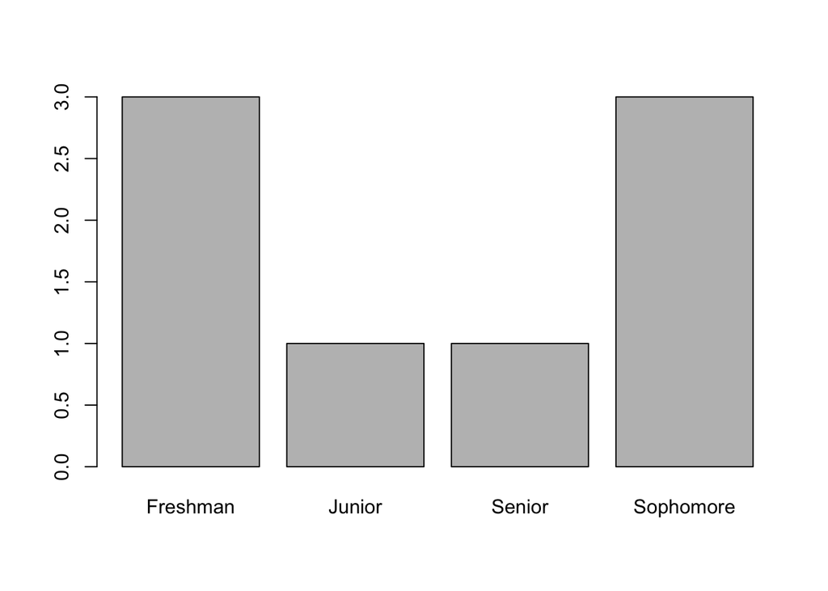

```r
barplot(table(schoolyear))
```

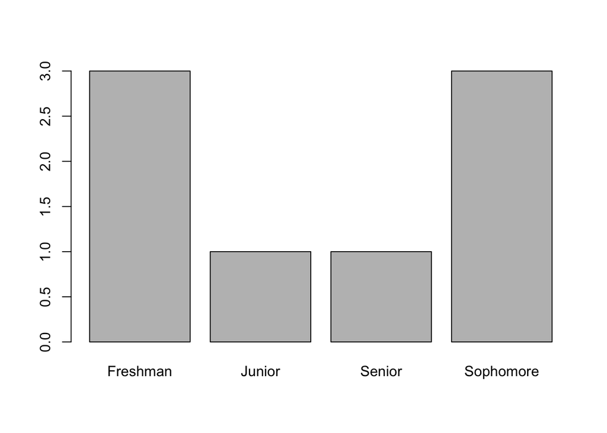

```r
barplot(table(schoolyear_factor))
```

## Reorder the levels of the factor.

However, the alphabetic order sometimes is not what we want (For instance, in our `schoolyear` example). So, we need to reorder the levels of the factor. The syntax of reordering the levels is the following:

```
newvector <- factor(vector, levels = c("level1", "level2", "level3", "level4"))
```

```r
schoolyear_factor <- factor(schoolyear, levels = c("Freshman", "Sophomore", "Junior", "Senior"))

levels(schoolyear_factor)
```

```
## [1] "Freshman"  "Sophomore" "Junior"    "Senior"
```

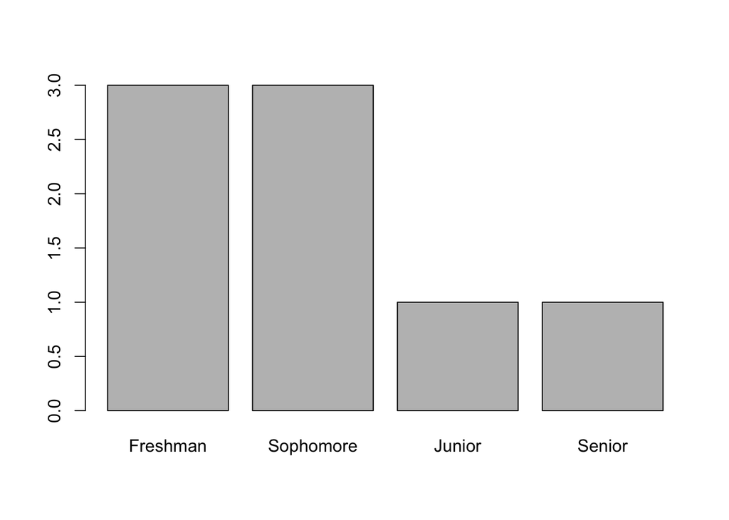

```r
barplot(table(schoolyear_factor))
```

## Reorder a factor / Re-assign levels to a factor

```r
levels(factor(gss$happy))
```

```
## [1] "DK"            "NOT TOO HAPPY" "PRETTY HAPPY"  "VERY HAPPY"
```

```r
gss$happy1 <- factor(gss$happy, levels = c("NOT TOO HAPPY", "PRETTY HAPPY", "VERY HAPPY"))
```

Now, we will assign levels into the new column

```r
gss$happy1[gss$happy == "NOT TOO HAPPY"] <- "NOT TOO HAPPY"
gss$Happy1[gss$happy == "PRETTY HAPPY"] <- "PRETTY HAPPY"
gss$happy1[gss$happy == "VERY HAPPY"] <- "VERY HAPPY"
# Now, we will deal with those missing data:
gss$happy1[gss$happy == " " | gss$happy == "DK"] <- NA

levels(gss$happy1)
```

```
## [1] "NOT TOO HAPPY" "PRETTY HAPPY"  "VERY HAPPY"
```

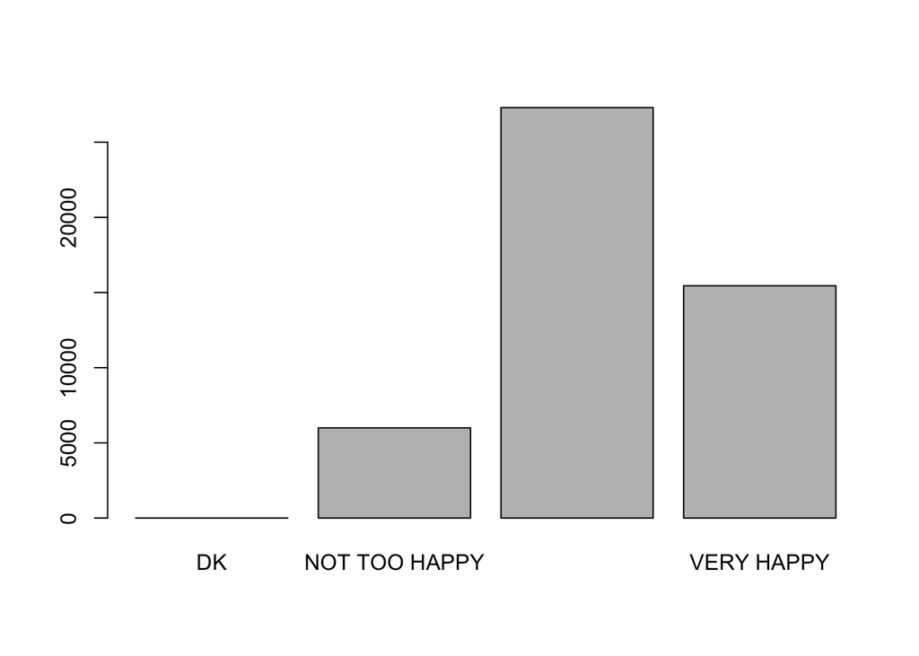

```r
barplot(table(gss$happy))
```

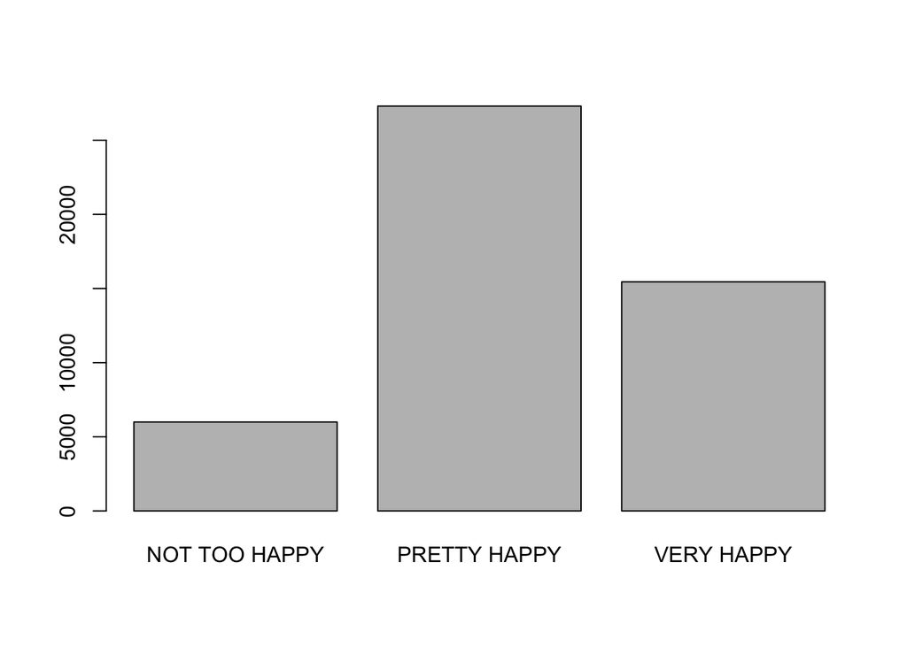

```r
barplot(table(gss$happy1))
```